# Bay Wheels Bike Sharing System Usage Trend in 2020

## by Osama Ghozlan

## Investigation Overview

> [Bay Wheels](https://en.wikipedia.org/wiki/Bay_Wheels) (formerly known as Ford GoBike) is the first regional public large-scale bicycle sharing system in California's San Francisco Bay Area and on the West Coast of the United States. It was established as Bay Area Bike Share in August 2013. As of January 2018, the Bay Wheels system had over 2,600 bicycles in 262 stations across San Francisco, East Bay and San Jose. The goal of the investigation is to gain insight about the usage, trends and behaviours of the users which use the system in order to increase its efficency and provide a more flexible sharing experience based on the data available from this year (2020)

## Dataset Overview

> Each trip data is anonymously collected and includes details such trip duration, start/end Time and date and so on. The dataset used for this exploratory analysis consists of [monthly individual trip data](https://www.lyft.com/bikes/bay-wheels/system-data) from January 2020 to August 2020 in CSV format covering the greater San Francisco Bay area which are available [here](https://s3.amazonaws.com/baywheels-data/index.html). This data was wrangled and used to provide the visualiztions below which were important in the facilitation of the exploratory analysis which is crucial for finding the behaviour of the users

```python
!rm *.csv
!rm -rfv __MACOSX
```

```
removed ‘__MACOSX/._202003-baywheels-tripdata.csv’
removed ‘__MACOSX/._202008-baywheels-tripdata.csv’
removed ‘__MACOSX/._202007-baywheels-tripdata.csv’
removed ‘__MACOSX/._202001-baywheels-tripdata.csv’
removed ‘__MACOSX/._202005-baywheels-tripdata.csv’
removed ‘__MACOSX/._202002-baywheels-tripdata.csv’
removed ‘__MACOSX/._202006-baywheels-tripdata.csv’
removed ‘__MACOSX/._202004-baywheels-tripdata.csv’
removed directory: ‘__MACOSX’
```

## Monthly usage of the two user types

> The bike usage between the two user types is fairly similar. The majority of the users in the first three months was dominated by the subscribers which became the complete opposite afterwards with the customers being the bigger group using the system. This could be as a result of the weather conditions in addition to the fact that many people found it more appealing to do activities outdoor (in the open air) which has little risk of being contaminated with the virus and helps break the general mood of the lockdown and curfews

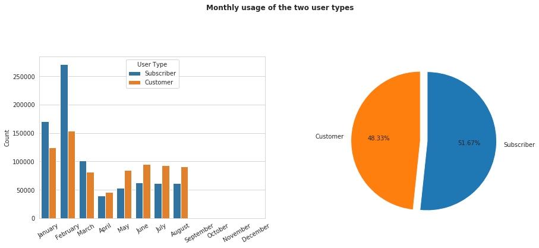

```python
plt.figure(figsize=[15, 5]);
base_color = sb.color_palette('colorblind')[0];
sb.set_style('whitegrid');

plot_var = pd.DataFrame(trips20_q1[['user_type', 'started_at_month']].append(trips20_q2[['user_type', 'started_at_month']]))
user_vals = plot_var['user_type'].value_counts()/len(plot_var);

plt.suptitle('Monthly usage of the two user types', fontsize=12, fontweight='semibold', y=1.125);

plt.subplot(1, 2, 1);
ax = sb.countplot(data=plot_var, x='started_at_month', hue='user_type', hue_order=user_vals.index);
ax.legend(title='User Type');
ax.tick_params(axis='x', labelrotation=30)
ax.set_xlabel('');
ax.set_ylabel('Count');

plt.subplot(1, 2, 2);
plt.pie(user_vals, explode=[0, 0.1], labels=user_vals.index, startangle=90, counterclock=False, autopct='%1.2f%%', shadow=False);
plt.axis('square');
```

## Monthly trip distances for each of the user types

> Customers had more (shorter) trips than the Subscribers (January has two white slots in the subscribers which indicates almost no activity) in both January and February while the Subscribers while the Subscribers overall had more trips the customers

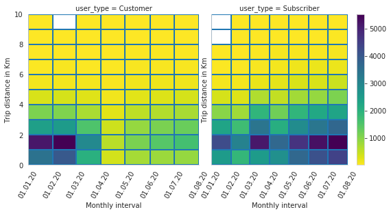

```python
bins_x = np.arange(0, 11, 1)
t_bins = []
for i in range(1,9):
    date = datetime.datetime(year=2020, month=i, day=1)
    t_bins.append(date.timestamp())
t_bins = mdates.epoch2num(t_bins)
d = df_t20[df_t20['trip_distance'] <= 10]
d = d.sample(round(len(d)/2), random_state=1)
grid = sb.FacetGrid(data=d, col='user_type', height=4)
# grid.map(plt.hist2d, 'started_at_month', 'trip_distance', cmin=0.5, cmap='viridis_r') #, bins=[bins_x, bins_y]);
grid.map(plt.hist2d, 'started_at_epoch', 'trip_distance', cmin=0.5, cmap='viridis_r', bins=[t_bins, bins_x]);
ax = plt.gca()
ax.xaxis.set_major_locator(mdates.MonthLocator())
ax.xaxis.set_major_formatter(mdates.DateFormatter('%d.%m.%y'))
for a in grid.axes.flatten():
    a.set_xlabel('Monthly interval')
    a.set_ylabel('Trip distance in Km')
    a.tick_params(axis='x', labelrotation=60)
plt.colorbar();
```

## The average trip duration for both user types on a weekly basis

> Customers tend to ride much longer trips in comparison to subscribers on every day of the week with a noticable increase in the trip duration for both user types on the weekends (Saturdays and Sundays) which shows that the subscribers mainly use the system for work and use it in an efficent manner

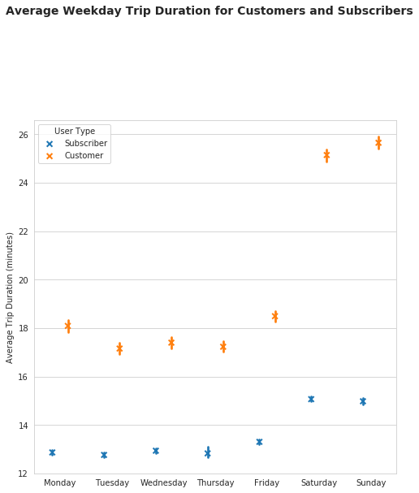

```python
d = pd.DataFrame(trips20_q1[['user_type', 'started_at_day', 'duration_min']].append(trips20_q2[['user_type', 'started_at_day', 'duration_min']]))
user_vals = d['user_type'].value_counts()/len(d);
plt.figure(figsize=[8, 8]);
plt.suptitle('Average Weekday Trip Duration for Customers and Subscribers', fontsize=14, fontweight='semibold', y=1.125);
ax = sb.pointplot(data=d, x='started_at_day', y='duration_min', hue='user_type', dodge=0.5, markers='x', linestyles="", hue_order=user_vals.index);
ax.legend(title='User Type');
ax.set_xlabel('');
ax.set_ylabel('Average Trip Duration (minutes)');
```